# 05-Complete_Snakemake_workflow

## Πλήρες Snakefile

Στην τελική του μορφή το Snakefile μας θα πρέπει να μοιάζει με το παρακάτω:

```python
SAMPLES = ["A", "B"]

rule all:
    input:
        expand("fastqc_untrimmed_reads/{sample}_fastqc.html", sample=SAMPLES),
        "multiqc_report.html",
        "calls/all.vcf"

rule fastqc_raw_reads:
    input:
        "raw_reads/{sample}.fastq"
    params:
        "fastqc_untrimmed_reads"
    output:
        "fastqc_untrimmed_reads/{sample}_fastqc.html",
    shell:
        "fastqc {input} -o {params}"

rule trim_reads:
    input:
        "raw_reads/{sample}.fastq"
    output:
        "trimmed_reads/{sample}_trim.fastq"
    shell:
        "trimmomatic SE {input} {output} SLIDINGWINDOW:4:20 MINLEN:25"

rule fastqc_trimmed_reads:
    input:
        "trimmed_reads/{sample}_trim.fastq"
    params:
        "fastqc_trimmed_reads"
    output:
        "fastqc_trimmed_reads/{sample}_trim_fastqc.html",
    shell:
        "fastqc {input} -o {params}"

rule multiqc:
    input:
        expand("fastqc_trimmed_reads/{sample}_trim_fastqc.html", sample=SAMPLES)
    params:
        "fastqc_trimmed_reads"
    output:
        "multiqc_report.html"
    shell:"multiqc {params} --force"

rule bwa_map:
    input:
        "reference/genome.fa",
        "trimmed_reads/{sample}_trim.fastq"
    output:
        "mapped_reads/{sample}.bam"
    shell:
        "bwa mem {input} | samtools view -Sb - > {output}"

rule samtools_sort:
    input:
        "mapped_reads/{sample}.bam"
    output:
        "sorted_reads/{sample}.bam"
    shell:
        "samtools sort -T sorted_reads/{wildcards.sample} "
        "-O bam {input} > {output}"

rule samtools_index:
    input:
        "sorted_reads/{sample}.bam"
    output:
        "sorted_reads/{sample}.bam.bai"
    shell:
        "samtools index {input}"

rule bcftools_call:
    input:
        fa="reference/genome.fa",
        bam=expand("sorted_reads/{sample}.bam", sample=SAMPLES),
        bai=expand("sorted_reads/{sample}.bam.bai", sample=SAMPLES)
    output:
        "calls/all.vcf"
    shell:
        "bcftools mpileup -f {input.fa} {input.bam} | "
        "bcftools call -mv - > {output}"
```

Μπορούμε να οπτικοποιήσουμε την πλήρη ροή εργασίας μας με την εντολή:

```bash
snakemake --dag | dot -Tpng > dag.png
```

Πλέον μπορούμε να εκτελέσουμε την πλήρη ροή εργασίας μας με την εντολή:

```bash
snakemake --cores 1
```

## Αρχεία VCF

Τα αρχεία VCF αποτελούνται από μία κεφαλίδα (header) και έναν πίνακα. Στην κεφαλίδα περιγράφεται η ημ/νία δημιουργίας του αρχείου, το λογισμικό και οι παράμετροι που χρησιμοποιήθηκαν, καθώς και τα περιεχόμενα στις στήλες INFO και FORMAT του πίνακα.

Μπορούμε να εξερευνήσουμε το αρχείο VCF που δημιουργήθηκε με την εντολή:

```bash
less -S calls/all.vcf
```

για να κλείσουμε την εξερεύνηση του αρχείου VCF, πατάμε το `q`.

Οι πρώτες στήλες του πίνακα είναι οι εξής:

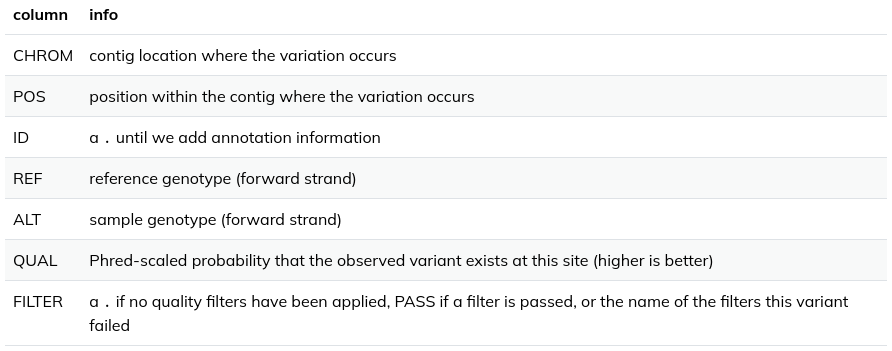

## Προαιρετικό Βήμα (Εξερεύνηση της χαρτογράφησης)

It is often instructive to look at your data in a genome browser. Visualization will allow you to get a “feel” for the data, as well as detecting abnormalities and problems. Also, exploring the data in such a way may give you ideas for further analyses. As such, visualization tools are useful for exploratory analysis.

Είναι συχνά ενδιαφέρον να εξετάσετε τα δεδομένα σας σε ένα genome browser. Η οπτικοποίηση θα σας επιτρέψει να αποκτήσετε μια “αίσθηση” για τα δεδομένα, καθώς και να ανιχνεύσετε προβλήματα. Επίσης, η εξερεύνηση των δεδομένων με αυτόν τον τρόπο μπορεί να σας δώσει ιδέες για περαιτέρω αναλύσεις.

Στο τερματικό μας μπορούμε να εκτελέσουμε την εντολή:

```bash
samtools tview sorted_reads/A.bam reference/genome.fa
```

- left and right arrows scroll
- q to quit
- CTRL-h and CTRL-l do “big” scrolls
- Typing g allows you to go to a specific location, in this format chromosome:location.